# Case Study 3

Michael Daniel Bigler and Liam Arthur Phan

2023-04-24

# **Packages**

```r
library(psych)
library(corrplot)
library(ggplot2)
library(car)
library(naniar)
library(REdaS)
library(zoo)
library(foreign)
library(lavaan)
library(ggcorrplot)
library(lares)
```

# 1 **Data**

```r
df <- read.csv2('Case Study III_Structural Equation Modeling.csv', na.strings = '999', sep = ',')
df <- df[, c(1:23, 25:36)]

DT::datatable(df)
```

|  | Im1 | Im2 | Im3 | Im4 | Im5 | Im6 | Im7 | Im8 | Im9 | Im10 | Im11 | Im12 | Im13 | Im14 | Im15 | Im16 | Im17 | Im18 | Im19 | Im20 | Im21 | Im22 | C_CR1 | C_CR3 | C_CR4 | C_REP1 | C_REP2 | C_REP3 | COM_A1 | … |
| --- | --- | --- | --- | --- | --- | --- | --- | --- | --- | --- | --- | --- | --- | --- | --- | --- | --- | --- | --- | --- | --- | --- | --- | --- | --- | --- | --- | --- | --- | --- |
| 1 | 7 | 7 | 4 | 4 | 4 | 7 |  |  | 6 | 7 | 7 | 6 | 4 | 7 | 5 | 5 | 4 | 4 | 5 | 4 | 5 | 4 | 6 | 6 | 6 | 5 |  | 5 | 5 | … |
| 2 | 4 | 4 |  | 4 | 3 | 5 | 3 | 5 | 4 | 5 | 4 | 5 | 5 | 5 | 4 | 4 | 4 | 3 | 2 | 2 | 6 | 2 | 1 |  |  | 3 | 4 | 4 |  | … |
| 3 | 5 | 5 | 7 | 7 | 7 | 4 |  | 6 | 6 | 7 | 7 | 7 | 7 | 7 | 6 | 6 | 6 | 5 | 6 | 7 | 7 | 6 |  | 1 | 2 | 5 | 5 | 5 | 4 | … |
| 4 | 5 | 5 | 5 | 5 | 5 | 4 | 4 | 4 | 4 | 4 | 6 | 6 | 6 | 5 | 6 | 5 | 4 | 4 | 5 | 4 | 3 | 2 | 2 | 5 | 3 | 4 | 5 | 5 | 5 | … |
| 5 | 4 | 4 | 4 | 3 | 5 | 4 | 4 | 4 | 3 | 6 | 5 | 4 | 4 | 6 | 4 | 3 | 3 | 3 | 3 | 3 | 3 | 3 | 2 | 2 | 1 | 4 | 5 | 5 | 4 | … |
| 6 | 4 | 4 | 5 | 5 |  | 4 | 2 | 5 | 3 | 3 | 5 | 3 | 3 |  | 3 | 3 | 5 | 5 | 3 | 4 | 5 | 5 | 5 | 5 | 2 | 5 | 5 | 5 |  | … |
| 7 | 4 | 5 | 6 | 6 | 6 | 7 | 7 | 6 | 7 | 5 | 5 | 6 | 6 | 6 | 4 | 3 | 5 | 4 | 4 | 2 | 4 | 2 | 4 | 4 | 4 | 4 | 4 | 5 | 3 | … |
| 8 | 7 | 7 | 4 | 4 | 4 | 6 | 7 | 6 | 4 | 6 | 5 | 7 | 6 | 6 | 5 | 4 | 3 | 3 | 6 | 5 | 6 | 4 | 6 | 6 | 1 | 5 | 5 | 5 | 4 | … |
| 9 | 4 | 4 | 4 | 4 | 5 | 5 | 5 | 5 | 5 | 6 | 6 | 6 | 6 | 6 | 5 | 5 | 5 | 5 | 5 | 6 | 6 | 5 | 5 | 5 | 5 | 4 | 4 | 5 | 4 | … |
| 10 | 4 | 4 | 3 | 3 | 4 | 5 | 5 | 4 | 5 | 4 | 5 | 4 | 5 | 4 | 4 | 4 | 5 | 5 | 4 | 5 | 5 |  | 1 | 2 | 3 | 4 | 4 | 4 | 4 | … |

[output cut: 543 more lines]

## 1.1 Dimensions

```r
dim_before_na <- dim(df)
dim_before_na
```

```
## [1] 553  35
```

## 1.2 Summary Statistics

```r
DT::datatable(describe(df))
```

|  | vars | n | mean | sd | median | trimmed | mad | min | max | range | skew | kurtosis | se |
| --- | --- | --- | --- | --- | --- | --- | --- | --- | --- | --- | --- | --- | --- |
| Im1 | 1 | 539 | 4.79220779220779 | 1.33492357572434 | 5 | 4.85219399538106 | 1.4826 | 1 | 7 | 6 | -0.436369600561195 | -0.200609855686631 | 0.0574992288893147 |
| Im2 | 2 | 535 | 4.85420560747664 | 1.29289910085328 | 5 | 4.9020979020979 | 1.4826 | 1 | 7 | 6 | -0.402962943679407 | -0.164894406615379 | 0.0558969025103941 |
| Im3 | 3 | 533 | 4.98499061913696 | 1.3249201458084 | 5 | 5.04215456674473 | 1.4826 | 1 | 7 | 6 | -0.524302389098627 | -0.220140087830794 | 0.0573886619727162 |
| Im4 | 4 | 543 | 5.00184162062615 | 1.34260181290144 | 5 | 5.06896551724138 | 1.4826 | 1 | 7 | 6 | -0.555799215003052 | -0.23279646431903 | 0.0576165585853223 |
| Im5 | 5 | 524 | 5.04007633587786 | 1.33073564449832 | 5 | 5.11904761904762 | 1.4826 | 1 | 7 | 6 | -0.680568038410379 | 0.0578742372793783 | 0.0581334565470813 |
| Im6 | 6 | 544 | 5.82352941176471 | 1.20393677716312 | 6 | 5.98853211009174 | 1.4826 | 1 | 7 | 6 | -1.156974440444 | 1.10627172632062 | 0.0516183634711268 |
| Im7 | 7 | 527 | 5.74952561669829 | 1.21064463031912 | 6 | 5.91016548463357 | 1.4826 | 2 | 7 | 5 | -1.05915146989703 | 0.720078165939059 | 0.0527365084039012 |
| Im8 | 8 | 547 | 5.9963436928702 | 1.06043799039628 | 6 | 6.16628701594533 | 1.4826 | 1 | 7 | 6 | -1.28050474989526 | 1.7558971214994 | 0.0453410543467968 |
| Im9 | 9 | 537 | 5.07635009310987 | 1.35345718617845 | 5 | 5.13921113689095 | 1.4826 | 1 | 7 | 6 | -0.431228364795847 | -0.450606616396302 | 0.0584059886157143 |
| Im10 | 10 | 547 | 6.10237659963437 | 0.88150191348671 | 6 | 6.21184510250569 | 1.4826 | 2 | 7 | 5 | -1.17672521617955 | 2.07392211073465 | 0.0376903001666983 |

[output cut: 25 more lines]

## 1.3 Missing Analysis

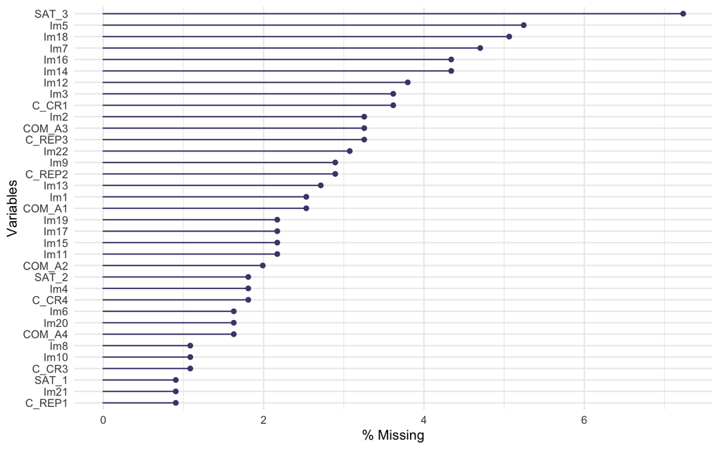

```r
gg_miss_var(df, show_pct = TRUE)
```

This is not too bad, we can see that SAT_3 is the one with the most NA values, up to 7%.

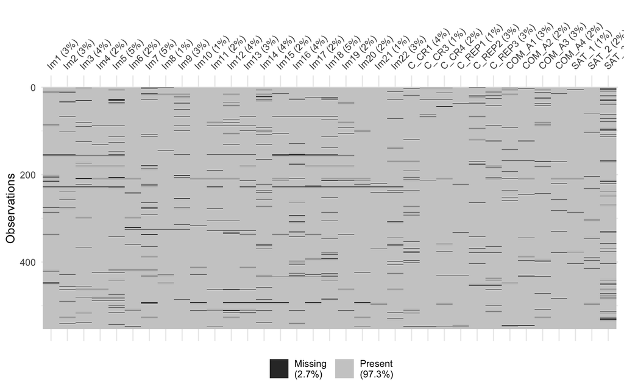

```r
naniar::vis_miss(df)
```

## 1.4 Dimensions after listwise deletion

```r
dim_after_na <- dim(na.omit(df))
dim_after_na
```

```
## [1] 309  35
```

```r
na_remove_count <- dim_after_na - dim_before_na
na_remove_count[1] <- abs(na_remove_count[1])
```

Thus, we remove a lot of observations with listwise deletion, up to 244

```r
# We should not do this
#df <- na.aggregate(df)

# But this
df_listwise <- na.omit(df)
```

# 2 **Exploratory Factor Analysis**

For exploratory factor analysis: please only consider variables image1 to image22, and use listwise deletion to handle missing data before starting exploratory factor analysis.

From Assistant

## 2.1 Check Assumptions

```r
df_1 <- df_listwise[,1:22]
```

### 2.1.1 Multicolinearity

```r
# Correlation Values Matrix
M <- cor(df_1)

# P-Value
p.mat <- cor_pmat(df_1)
```

**Correlation Plot**

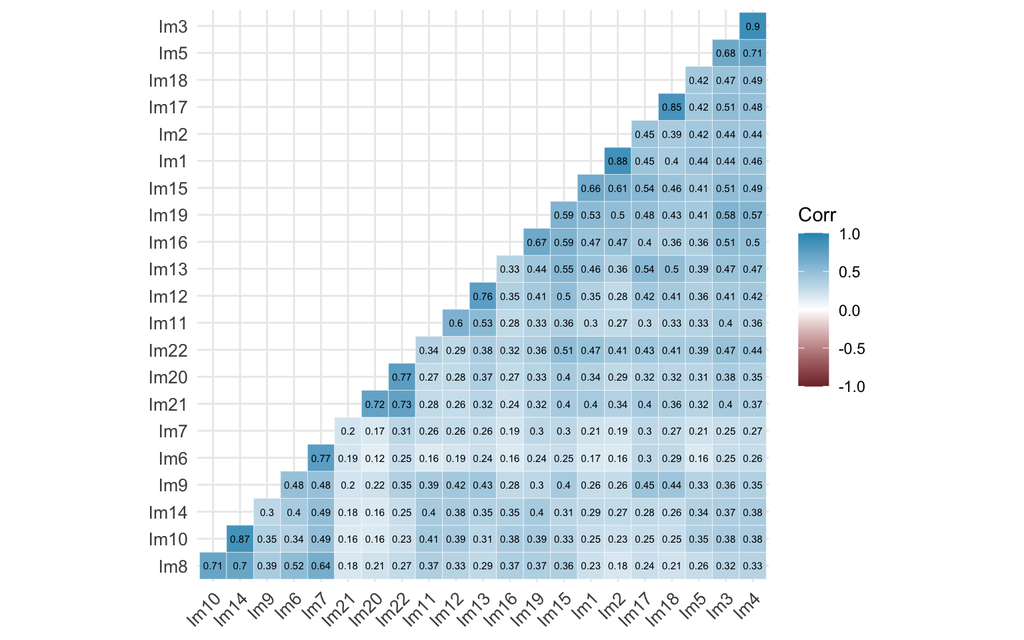

```r
# Correlation Plot
ggcorrplot(M, hc.order = TRUE, type = "lower", lab = TRUE, p.mat = p.mat, sig.level=0.05, lab_size = 2, tl.cex = 10,outline.col = "white", ggtheme = ggplot2::theme_minimal(), colors = c("#823038", "white", "#2596be"))
```

**Correlation Ranking**

```r
# Ranked Cross-Correlations
corr_cross(df_1, # name of dataset
  max_pvalue = 0.05, # display only significant correlations (at 5% level)
  top = 9 # display top 10 couples of variables (by correlation coefficient)
)
```

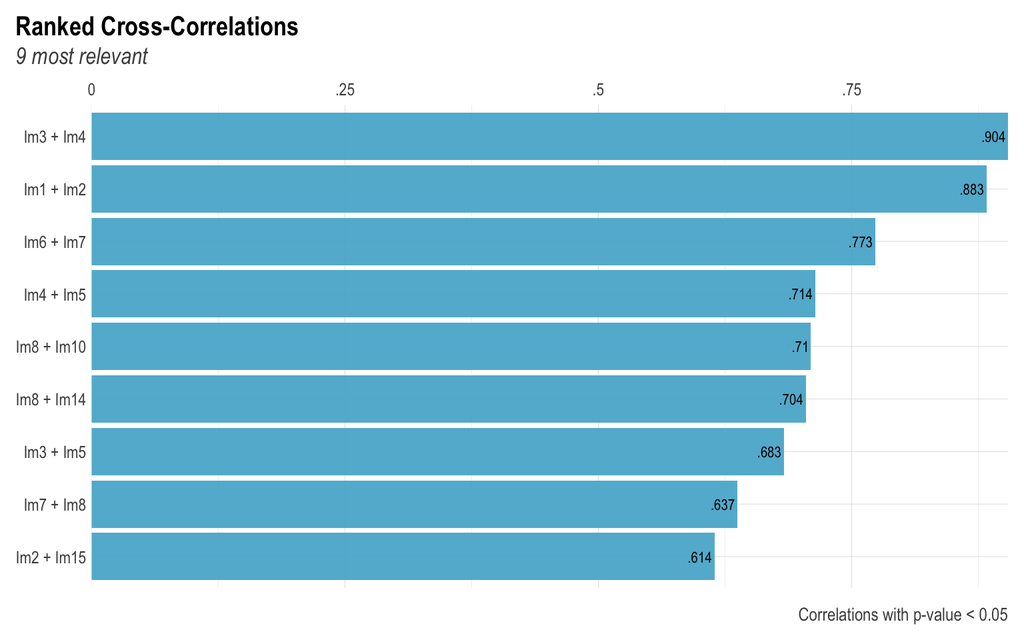

As we can see, We have some multicolinearity amongst the variables, at least 6 variables can be considered with high-colinearity. Im3+Im4, Im1+Im2m, Im6+Im7, Im4+Im5, Im8+Im10 and Im8+Im14.

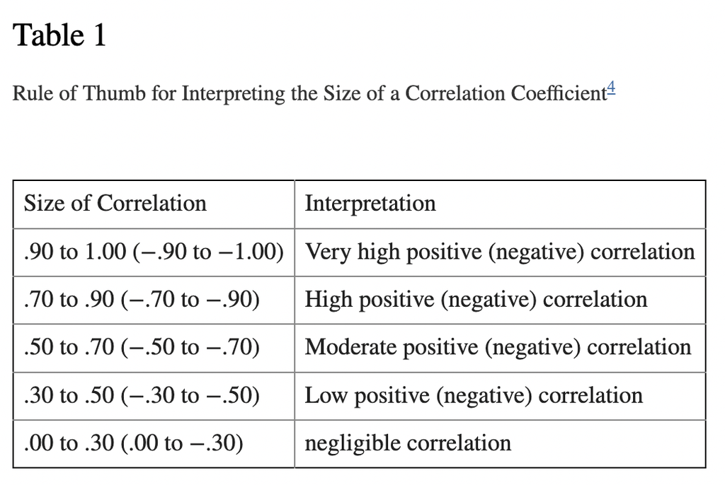

[A guide to appropriate use of Correlation coefficient in medical research](https://www.ncbi.nlm.nih.gov/pmc/articles/PMC3576830/#:~:text=A%20correlation%20coefficient%20of%20zero,between%20%E2%88%921%20and%20%2B1.)

### 2.1.2 **Kaiser–Meyer–Olkin test (KMO)**

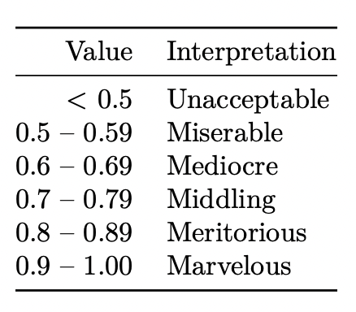

[KMO: Find the Kaiser, Meyer, Olkin Measure of Sampling Adequacy](https://www.rdocumentation.org/packages/psych/versions/2.3.3/topics/KMO)

**KMO Index**

```r
KMOTEST <- KMO(M)
sort(KMOTEST$MSAi)
```

```
##       Im6      Im10      Im14       Im2       Im1       Im7      Im20      Im17
## 0.7791619 0.8192843 0.8206186 0.8275596 0.8316756 0.8342908 0.8369658 0.8459668
##      Im18       Im4       Im3      Im13      Im12      Im22      Im21      Im11
## 0.8479170 0.8623498 0.8647696 0.8749019 0.8763560 0.8850423 0.8930068 0.9101259
##      Im16       Im8       Im9      Im19      Im15       Im5
## 0.9168866 0.9231784 0.9240378 0.9432565 0.9558911 0.9616355
```

No problem seen in each factor anti-image correlation.

**KMO Overall Measure of sampling adequacy**

```r
KMOTEST$MSA
```

```
## [1] 0.8739058
```

With 0.87 sampling adequacy is very high.

### 2.1.3 **Bartlett’s Test of Sphericity**

```r
cortest.bartlett(df_1)
```

```
## $chisq
## [1] 5268.134
##
## $p.value
## [1] 0
##
## $df
## [1] 231
```

Factor analysis can be done as the test indicates a p-value under 0 (P-value < 0).

## 2.2 Factor analysis

```r
parallel <- fa.parallel(df_1)
```

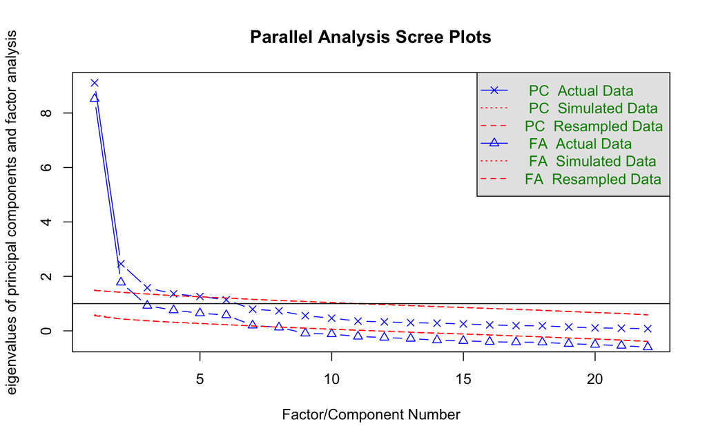

```
## Parallel analysis suggests that the number of factors =  6  and the number of components =  4
```

```r
parallel$fa.values
```

```
##  [1]  8.52131727  1.77870726  0.92459418  0.75887484  0.64852555  0.57804609
##  [7]  0.20090803  0.12795249 -0.09194084 -0.11850461 -0.20686151 -0.24648678
## [13] -0.28508118 -0.34181773 -0.36644485 -0.40124099 -0.41642213 -0.42128097
## [19] -0.47389119 -0.50551434 -0.54257085 -0.59955031
```

```r
parallel$pc.values
```

```
##  [1] 9.10829936 2.46361323 1.57989449 1.36098729 1.26167043 1.13847243
##  [7] 0.79288548 0.73235595 0.55624052 0.46492834 0.35686479 0.32912690
## [13] 0.29918445 0.28262082 0.25462974 0.21768017 0.19124012 0.18433248
## [19] 0.14293313 0.10782917 0.09530368 0.07890703
```

### 2.2.1 Factors Quantity

#### 2.2.1.1 Scree-plot

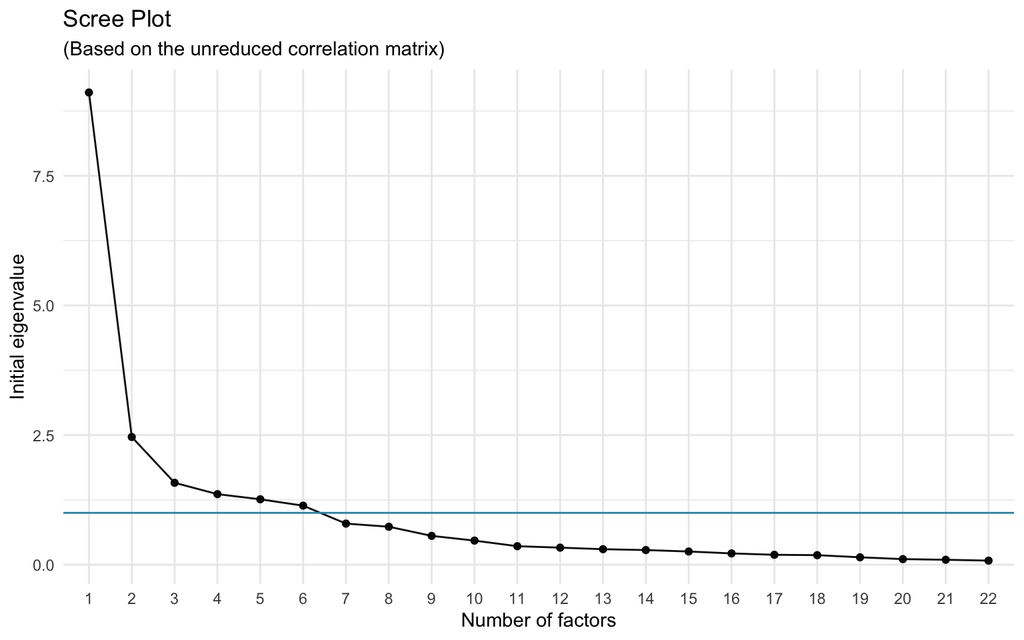

```r
fa_result <- fa(df_1, rotate = "varimax", fm = "pa")
n_factors <- length(fa_result$e.values)
scree <- data.frame(Factor_n =  as.factor(1:n_factors), Eigenvalue = fa_result$e.values)

ggplot(scree, aes(x = Factor_n, y = Eigenvalue, group = 1)) +
  geom_point() + geom_line() +
  xlab("Number of factors") +
  ylab("Initial eigenvalue") +
  labs( title = "Scree Plot",
        subtitle = "(Based on the unreduced correlation matrix)") +
  geom_hline(yintercept = 1, color="#2596be") + theme_minimal()
```

Look at the elbow: would only select 3-4 factors

#### 2.2.1.2 Kaisers-Criterion

```r
factors_kaiser <- sum(fa_result$e.values>1)

print(paste("Kaiser-Criterion:", factors_kaiser,"Factors"))
```

```
## [1] "Kaiser-Criterion: 6 Factors"
```

According to factor analysis six factors.

### 2.2.2 Factors Loadings

```r
fa_result <- fa(df_1, rotate = "varimax", fm = "pa", nfactors = 6)
colnames(fa_result$loadings) <- c('French cuisine', 'Appealing store', 'Large assortment', 'Luxury and high quality', 'Relaxing store', 'Hip and Trendy')

cutoff_1 <- 0.3

print(fa_result$loadings, cutoff=cutoff_1,sort=TRUE)
```

```
##
## Loadings:
##      French cuisine Appealing store Large assortment Luxury and high quality
## Im1   0.850
## Im2   0.842
## Im15  0.589                                           0.346
## Im3                  0.831
## Im4                  0.850
## Im5                  0.603
## Im8                                  0.725
## Im10                                 0.821
## Im14                                 0.794
## Im11                                 0.317            0.537
## Im12                                                  0.796
## Im13                                                  0.748
## Im20
## Im21
## Im22
## Im6
## Im7                                  0.445
## Im9                                                   0.365
## Im16  0.468          0.365
## Im17  0.349          0.366                            0.439
## Im18                 0.374                            0.438
## Im19  0.478          0.405
##      Relaxing store Hip and Trendy
## Im1
## Im2
## Im15
## Im3
## Im4
## Im5
## Im8                  0.378
## Im10
## Im14
## Im11
## Im12
## Im13
## Im20  0.839
## Im21  0.766
## Im22  0.798
## Im6                  0.783
## Im7                  0.739
## Im9                  0.480
## Im16
## Im17                 0.416
## Im18                 0.395
## Im19
##
##                French cuisine Appealing store Large assortment
## SS loadings             2.864           2.782            2.608
## Proportion Var          0.130           0.126            0.119
## Cumulative Var          0.130           0.257            0.375
##                Luxury and high quality Relaxing store Hip and Trendy
## SS loadings                      2.514          2.395          2.080
## Proportion Var                   0.114          0.109          0.095
## Cumulative Var                   0.489          0.598          0.693
```

With six factors we clear loadings except for some variables.

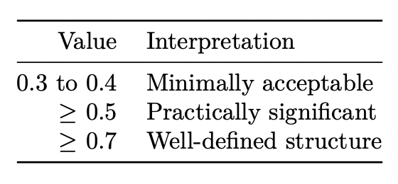

[Exploratory factor analysis and Cronbach’s alpha Questionnaire Validation Workshop, 10/10/2017, USM Health Campus](https://wnarifin.github.io/workshop/qvw2017/efa.pdf)

### 2.2.3 Communalities

```r
sort(fa_result$communality)
```

```
##       Im9      Im11      Im16       Im5      Im19      Im18      Im15      Im17
## 0.4526450 0.4610796 0.4613449 0.5243697 0.5406231 0.6045162 0.6408292 0.6663545
##      Im21       Im6       Im8      Im13      Im12      Im14       Im7      Im20
## 0.6804910 0.7082026 0.7156365 0.7251873 0.7583907 0.7598094 0.7674206 0.7746026
##      Im10       Im2      Im22       Im1       Im3       Im4
## 0.7933128 0.7958673 0.8037973 0.8414084 0.8743453 0.8933325
```

Only some communalities under 0.5. Need to look out for lm11, lm16, lm9 and lm16

```r
# FACTOR 1
French_cuisine <- fa_result$loadings[,1]
French_cuisine <- French_cuisine[French_cuisine>0.3]

French_cuisine_Names <- names(French_cuisine)

# FACTOR 2
Appealing_store <- fa_result$loadings[,2]
Appealing_store <- Appealing_store[Appealing_store>0.3]

Appealing_store_Names <- names(Appealing_store)

# FACTOR 3
Large_assortment <- fa_result$loadings[,3]
Large_assortment <- Large_assortment[Large_assortment>0.3]

Large_assortment_Names <- names(Large_assortment)

# FACTOR 4
Luxury_quality <- fa_result$loadings[,4]
Luxury_quality <- Luxury_quality[Luxury_quality>0.3]

Luxury_quality_Names <- names(Luxury_quality)

# FACTOR 5
Relaxing_store <- fa_result$loadings[,5]
Relaxing_store <- Relaxing_store[Relaxing_store>0.3]

Relaxing_store_Names <- names(Relaxing_store)

# FACTOR 6
Hip_and_Trendy <- fa_result$loadings[,6]
Hip_and_Trendy <- Hip_and_Trendy[Hip_and_Trendy>0.3]

Hip_and_Trendy_Names <- names(Hip_and_Trendy)
```

### 2.2.4 Cronbach’s alpha

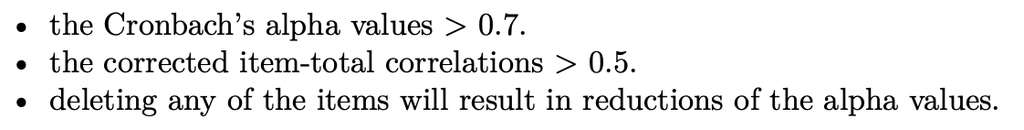

**French cuisine**

```r
alpha.pa1 = psych::alpha(df_1[French_cuisine_Names])
alpha.pa1$item.stats
```

```
##        n     raw.r     std.r     r.cor    r.drop     mean       sd
## Im1  309 0.8460577 0.8391499 0.8443867 0.7585425 4.799353 1.355077
## Im2  309 0.8304086 0.8243349 0.8246681 0.7421684 4.896440 1.282609
## Im15 309 0.8383053 0.8409447 0.7977299 0.7592756 5.029126 1.215081
## Im16 309 0.7494359 0.7545544 0.6891356 0.6336770 5.097087 1.244582
## Im17 309 0.7000215 0.6996719 0.5951626 0.5634328 4.964401 1.279976
## Im19 309 0.7884029 0.7945033 0.7394278 0.6908478 5.067961 1.205470
```

**Appealing store**

```r
alpha.pa1 = psych::alpha(df_1[Appealing_store_Names])
alpha.pa1$item.stats
```

```
##        n     raw.r     std.r     r.cor    r.drop     mean       sd
## Im3  309 0.8614431 0.8578662 0.8612239 0.7984627 4.912621 1.344349
## Im4  309 0.8631312 0.8583998 0.8636457 0.7986800 4.912621 1.380101
## Im5  309 0.7468437 0.7401841 0.6797456 0.6420115 4.902913 1.359296
## Im16 309 0.6909311 0.7015376 0.6298228 0.5816876 5.097087 1.244582
## Im17 309 0.7626319 0.7616928 0.7440530 0.6699658 4.964401 1.279976
## Im18 309 0.7466974 0.7421720 0.7212159 0.6379898 4.511327 1.399455
## Im19 309 0.7541259 0.7650931 0.7106447 0.6655546 5.067961 1.205470
```

**Large assortment**

```r
alpha.pa1 = psych::alpha(df_1[Large_assortment_Names])
alpha.pa1$item.stats
```

```
##        n     raw.r     std.r     r.cor    r.drop     mean        sd
## Im7  309 0.7488397 0.7267161 0.6234566 0.5649837 5.760518 1.1846945
## Im8  309 0.8614935 0.8630823 0.8307826 0.7647217 6.022654 1.0395451
## Im10 309 0.8554473 0.8792672 0.8896831 0.7758982 6.097087 0.8773621
## Im11 309 0.6346359 0.6139485 0.4398851 0.4098528 5.627832 1.1540452
## Im14 309 0.8534662 0.8773368 0.8866227 0.7728265 6.116505 0.8786904
```

**Luxury and High quality**

```r
alpha.pa1 = psych::alpha(df_1[Luxury_quality_Names])
alpha.pa1$item.stats
```

```
##        n     raw.r     std.r     r.cor    r.drop     mean       sd
## Im9  309 0.6829813 0.6735786 0.5740335 0.5469390 5.032362 1.357610
## Im11 309 0.6559353 0.6708223 0.5896621 0.5374135 5.627832 1.154045
## Im12 309 0.7720969 0.7857649 0.7619985 0.6855246 5.647249 1.146069
## Im13 309 0.8183859 0.8246634 0.8066052 0.7366646 5.372168 1.269268
## Im15 309 0.7242892 0.7281008 0.6532799 0.6166705 5.029126 1.215081
## Im17 309 0.7974072 0.7853878 0.7854698 0.7070819 4.964401 1.279976
## Im18 309 0.7781458 0.7634824 0.7555657 0.6694565 4.511327 1.399455
```

**Relaxing store**

```r
alpha.pa1 = psych::alpha(df_1[Relaxing_store_Names])
alpha.pa1$item.stats
```

```
##        n     raw.r     std.r     r.cor    r.drop     mean       sd
## Im20 309 0.9140957 0.9130475 0.8485597 0.8022811 4.679612 1.485079
## Im21 309 0.8944952 0.8998429 0.8159090 0.7740323 5.132686 1.399861
## Im22 309 0.9188570 0.9147850 0.8524899 0.8055555 4.220065 1.538505
```

**Hip and Trendy**

```r
alpha.pa1 = psych::alpha(df_1[Hip_and_Trendy_Names])
alpha.pa1$item.stats
```

```
##        n     raw.r     std.r     r.cor    r.drop     mean       sd
## Im6  309 0.7538826 0.7683868 0.7291794 0.6282693 5.805825 1.225208
## Im7  309 0.7663559 0.7875750 0.7649939 0.6506426 5.760518 1.184694
## Im8  309 0.6491467 0.6826395 0.5887581 0.5172011 6.022654 1.039545
## Im9  309 0.7510639 0.7396460 0.6381938 0.6064875 5.032362 1.357610
## Im17 309 0.7383815 0.7147163 0.6991001 0.5994648 4.964401 1.279976
## Im18 309 0.7254902 0.6973341 0.6793165 0.5642905 4.511327 1.399455
```

### 2.2.5 Diagram

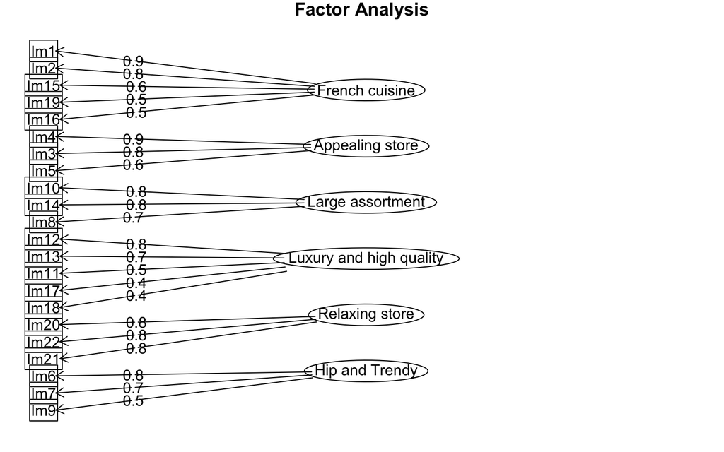

```r
fa.diagram(fa_result)
```

# 3 **Confirmatory Factor Analysis**

For confirmatory factor analysis (CFA) and structural equation modeling (SEM), please use the raw data (which includes the missing values) to perform CFA and SEM, and use maximum likelihood (ML) to handle the missing data.

From Assistant

```r
model <- "
F1 =~Im6+Im7+Im8+Im10+Im14+Im9
F2 =~Im3+Im4+Im5
F3 =~Im1+Im2+Im15+Im16+Im19
F4 =~Im11+Im12+Im13
F5 =~Im20+Im21+Im22
F6 =~Im17+Im18+Im9+Im6
"
fit <- cfa(model, data=df_1)
summary(fit, fit.measures=TRUE, standardized=TRUE)
```

```
## lavaan 0.6.15 ended normally after 64 iterations
##
##   Estimator                                         ML
##   Optimization method                           NLMINB
##   Number of model parameters                        61
##
##   Number of observations                           309
##
## Model Test User Model:
##
##   Test statistic                               922.622
##   Degrees of freedom                               192
##   P-value (Chi-square)                           0.000
##
## Model Test Baseline Model:
##
##   Test statistic                              5429.194
##   Degrees of freedom                               231
##   P-value                                        0.000
##
## User Model versus Baseline Model:
##
##   Comparative Fit Index (CFI)                    0.859
##   Tucker-Lewis Index (TLI)                       0.831
##
## Loglikelihood and Information Criteria:
##
##   Loglikelihood user model (H0)              -8864.482
##   Loglikelihood unrestricted model (H1)      -8403.172
##
##   Akaike (AIC)                               17850.965
##   Bayesian (BIC)                             18078.699
##   Sample-size adjusted Bayesian (SABIC)      17885.231
##
## Root Mean Square Error of Approximation:
##
##   RMSEA                                          0.111
##   90 Percent confidence interval - lower         0.104
##   90 Percent confidence interval - upper         0.118
##   P-value H_0: RMSEA <= 0.050                    0.000
```

[output cut: 83 more lines]

```
##    .Im19              0.869    0.074   11.813    0.000    0.869    0.600
##    .Im11              0.760    0.068   11.229    0.000    0.760    0.573
##    .Im12              0.331    0.047    7.037    0.000    0.331    0.253
##    .Im13              0.365    0.057    6.401    0.000    0.365    0.227
##    .Im20              0.602    0.070    8.547    0.000    0.602    0.274
##    .Im21              0.618    0.066    9.350    0.000    0.618    0.317
##    .Im22              0.454    0.070    6.488    0.000    0.454    0.192
##    .Im17              0.188    0.051    3.675    0.000    0.188    0.115
##    .Im18              0.374    0.061    6.100    0.000    0.374    0.192
##     F1                0.253    0.069    3.640    0.000    1.000    1.000
##     F2                1.597    0.147   10.848    0.000    1.000    1.000
##     F3                1.570    0.150   10.477    0.000    1.000    1.000
##     F4                0.567    0.092    6.151    0.000    1.000    1.000
##     F5                1.596    0.178    8.987    0.000    1.000    1.000
##     F6                1.445    0.139   10.372    0.000    1.000    1.000
```

Remove Im16, Im9 and Im6

```r
library(dplyr)
modificationindices(fit) %>% filter(mi>10)
```

```
##     lhs op  rhs      mi    epc sepc.lv sepc.all sepc.nox
## 1    F1 =~ Im16  19.396  0.577   0.290    0.233    0.233
## 2    F1 =~ Im19  25.761  0.617   0.310    0.258    0.258
## 3    F1 =~ Im11  13.402  0.464   0.233    0.202    0.202
## 4    F2 =~  Im1  19.720 -0.192  -0.242   -0.179   -0.179
## 5    F2 =~  Im2  10.749 -0.136  -0.172   -0.134   -0.134
## 6    F2 =~ Im15  12.821  0.178   0.225    0.186    0.186
## 7    F2 =~ Im16  27.046  0.312   0.395    0.317    0.317
## 8    F2 =~ Im19  46.033  0.378   0.478    0.397    0.397
## 9    F4 =~  Im9  10.776  0.428   0.322    0.238    0.238
## 10   F4 =~  Im2  31.130 -0.386  -0.291   -0.227   -0.227
## 11   F4 =~ Im15  42.950  0.549   0.414    0.341    0.341
## 12   F4 =~ Im19  20.032  0.420   0.317    0.263    0.263
## 13   F5 =~  Im2  12.235 -0.141  -0.179   -0.139   -0.139
## 14   F5 =~ Im15  17.278  0.204   0.258    0.213    0.213
```

[output cut: 31 more lines]

# 4 **Structure Equation Modelling**

```r
model <- "
F1 =~Im6+Im7+Im8+Im10+Im14+Im9
F2 =~Im3+Im4+Im5
F3 =~Im1+Im2+Im15+Im16+Im19
F4 =~Im11+Im12+Im13
F5 =~Im20+Im21+Im22
F6 =~Im17+Im18+Im9+Im6

CS ~ F1 + F2 + F3 + F4 + F5 + F6
AC ~ F1 + F2 + F3 + F4 + F5 + F6

CS =~ SAT_1 + SAT_2 + SAT_3
AC =~ COM_A1 + COM_A2 + COM_A3 + COM_A4

RI =~ C_REP1 + C_REP2 + C_REP3
CI =~ C_CR1 + C_CR3 + C_CR4

RI ~ CS + AC + F1 + F2 + F3 + F4 + F5 + F6
CI ~ CS + AC + F1 + F2 + F3 + F4 + F5 + F6
"

fit10<-cfa(model, data=df, missing="ML")

inspect(fit10)
```

```
## $lambda
##        F1 F2 F3 F4 F5 F6 CS AC RI CI
## Im6     0  0  0  0  0 18  0  0  0  0
## Im7     1  0  0  0  0  0  0  0  0  0
## Im8     2  0  0  0  0  0  0  0  0  0
## Im10    3  0  0  0  0  0  0  0  0  0
## Im14    4  0  0  0  0  0  0  0  0  0
## Im9     5  0  0  0  0 17  0  0  0  0
## Im3     0  0  0  0  0  0  0  0  0  0
## Im4     0  6  0  0  0  0  0  0  0  0
## Im5     0  7  0  0  0  0  0  0  0  0
## Im1     0  0  0  0  0  0  0  0  0  0
## Im2     0  0  8  0  0  0  0  0  0  0
## Im15    0  0  9  0  0  0  0  0  0  0
## Im16    0  0 10  0  0  0  0  0  0  0
## Im19    0  0 11  0  0  0  0  0  0  0
## Im11    0  0  0  0  0  0  0  0  0  0
## Im12    0  0  0 12  0  0  0  0  0  0
## Im13    0  0  0 13  0  0  0  0  0  0
## Im20    0  0  0  0  0  0  0  0  0  0
## Im21    0  0  0  0 14  0  0  0  0  0
## Im22    0  0  0  0 15  0  0  0  0  0
## Im17    0  0  0  0  0  0  0  0  0  0
## Im18    0  0  0  0  0 16  0  0  0  0
## SAT_1   0  0  0  0  0  0  0  0  0  0
## SAT_2   0  0  0  0  0  0 31  0  0  0
## SAT_3   0  0  0  0  0  0 32  0  0  0
## COM_A1  0  0  0  0  0  0  0  0  0  0
## COM_A2  0  0  0  0  0  0  0 33  0  0
## COM_A3  0  0  0  0  0  0  0 34  0  0
## COM_A4  0  0  0  0  0  0  0 35  0  0
## C_REP1  0  0  0  0  0  0  0  0  0  0
## C_REP2  0  0  0  0  0  0  0  0 36  0
## C_REP3  0  0  0  0  0  0  0  0 37  0
## C_CR1   0  0  0  0  0  0  0  0  0  0
## C_CR3   0  0  0  0  0  0  0  0  0 38
## C_CR4   0  0  0  0  0  0  0  0  0 39
##
## $theta
##        Im6 Im7 Im8 Im10 Im14 Im9 Im3 Im4 Im5 Im1 Im2 Im15 Im16 Im19 Im11 Im12
```

[output cut: 169 more lines]

```
## C_CR3     150
## C_CR4     151
##
## $alpha
##    intrcp
## F1      0
## F2      0
## F3      0
## F4      0
## F5      0
## F6      0
## CS      0
## AC      0
## RI      0
## CI      0
```